# XDAS_Bioconductor_GOstats_GSEA

Manpreet S. Katari

# Bioconductor

[Bioconductor](http://bioconductor.org) is a great resource for R packages that can help researchers analyze high throughput genomic data. I specially find the [Common Work flows](http://bioconductor.org/packages/release/BiocViews.html#___Workflow) very helpful.

To begin using Bioconductor, you must first install **BiocManager**

```r
install.packages("BiocManager")
```

Once the BiocManager is installed, you install specific packages using the **BiocManager::install()** function that same way you use **install.packages()** in the past. Note that packages in Bioconductor must be installed using BiocManager.

For today’s exercise we are going to use **GOstats** and to perform GSEA we will use functions in the **limma** package.

```r
BiocManager::install("GOstats")
```

The GOstats package using Hypergeometric test to determine if a GO-term is statistically significant. Fortunately it uses an R package to look up the different GO-terms and also the different annotations for each gene. In this example we will use a gene list from an experiment which involved Arabidopsis so we will load the Arabidopsis genome data

```r
BiocManager::install("org.At.tair.db")
```

Let’s load the list of genes that we have identified to be differentially expressed using an RNA-seq workflow.

```r
data = read.table("RNAseq2019_deseq_results.txt",
                  header=T, row.names = 1)

head(data)
```

```
##            baseMean log2FoldChange     lfcSE       stat     pvalue      padj
## AT1G01010  31.40465     -0.6078494 0.5140180 -1.1825448 0.23698961 0.9999967
## AT1G01040  59.76047      0.4011031 0.3898797  1.0287868 0.30357986 0.9999967
## AT1G01050  30.30432      0.6566004 0.4965874  1.3222254 0.18609310 0.9999967
## AT1G01060  85.55972     -0.2662260 0.3726559 -0.7144016 0.47497886 0.9999967
## AT1G01090 130.12687      0.2773215 0.3094337  0.8962227 0.37013385 0.9999967
## AT1G01100 808.87712      0.4127319 0.2402104  1.7182103 0.08575826 0.9493344
```

```r
dim(data)
```

```
## [1] 12639     6
```

```r
# A common way to filter the data is to look for
# genes that have a significnat adjusted p-value
# and a fold change greater than 1.5

sig_genes = subset(data, padj < 0.05 & abs(log2FoldChange) > 1.5)

dim(sig_genes)
```

```
## [1] 202   6
```

# Annotations

The species databases are very useful in retrieving different types of data about your gene(s) of interested. Since identifiers are often not very helpful, it is nice to be able to retrieve the symbol or a short description of the genes using the database.

Here are some commands that allow you to make the most of the AnnotationDBI package. Once you have installed the species database of choice from Bioconductor, you need to load it first using the library command.

```r
library(org.At.tair.db)
```

In the package we will be able to *select* specific *columns* using *keys*, which refers to the column you can use to query the database.

To see what columns are available, you can use the **columns()** function.

```r
columns(org.At.tair.db)
```

```
##  [1] "ARACYC"       "ARACYCENZYME" "ENTREZID"     "ENZYME"       "EVIDENCE"
##  [6] "EVIDENCEALL"  "GENENAME"     "GO"           "GOALL"        "ONTOLOGY"
## [11] "ONTOLOGYALL"  "PATH"         "PMID"         "REFSEQ"       "SYMBOL"
## [16] "TAIR"
```

To see what keys are available to query, you can use the **keytypes()** function.

```r
keytypes(org.At.tair.db)
```

```
##  [1] "ARACYC"       "ARACYCENZYME" "ENTREZID"     "ENZYME"       "EVIDENCE"
##  [6] "EVIDENCEALL"  "GENENAME"     "GO"           "GOALL"        "ONTOLOGY"
## [11] "ONTOLOGYALL"  "PATH"         "PMID"         "REFSEQ"       "SYMBOL"
## [16] "TAIR"
```

The annotation package ( which loaded automatically when you loaded the Arabidopsis annotations) allows you to select information about specific genes and also retrieve specific information. It’s like using filter and select in dplyr. **keys** is a vector of values you want to query, **keytype** is what type of values you are querying, **columns** is a character vector of all columns you want back.

```r
# If you want all results
genedesc = select(org.At.tair.db,
                  keys = rownames(sig_genes),
                  columns = c("SYMBOL","GENENAME"),
                  keytype = "TAIR")
head(genedesc)
```

```
##        TAIR   SYMBOL
## 1 AT1G03850 ATGRXS13
## 2 AT1G03850   GRXS13
## 3 AT1G07150 MAPKKK13
## 4 AT1G08090     ACH1
## 5 AT1G08090 ATNRT2.1
## 6 AT1G08090 ATNRT2:1
##                                                                                                                                           GENENAME
## 1                                                                                                                                             <NA>
## 2                                                                                                                                             <NA>
## 3                                                                                                                         member of MEKK subfamily
## 4 High-affinity nitrate transporter. Up-regulated by nitrate. Functions as a repressor of lateral root initiation independently of nitrate uptake.
## 5 High-affinity nitrate transporter. Up-regulated by nitrate. Functions as a repressor of lateral root initiation independently of nitrate uptake.
## 6 High-affinity nitrate transporter. Up-regulated by nitrate. Functions as a repressor of lateral root initiation independently of nitrate uptake.
```

In the example above, you get multiple entries for cases where there is more than one result. For example NRT2.1 has many different symbols for it is repeated several time. You can ask for it to presented in just one row but you have to then restrict the number of results you want. A better way to do this is use the **mapIds()** function and specify how to report the multiple results using **multiVals**.

```r
# if you want only one result back

genesymbols=mapIds(org.At.tair.db,
                   keys = rownames(sig_genes),
                   column = c("SYMBOL"),
                   keytype = "TAIR",
                   multiVals="CharacterList")
head(genesymbols)
```

```
## CharacterList of length 6
## [["AT1G03850"]] ATGRXS13 GRXS13
## [["AT1G07150"]] MAPKKK13
## [["AT1G08090"]] ACH1 ATNRT2.1 ATNRT2:1 LIN1 NRT2 NRT2.1 NRT2:1 NRT2;1AT
## [["AT1G08100"]] ACH2 ATNRT2.2 NRT2.2 NRT2;2AT
## [["AT1G08650"]] ATPPCK1 PPCK1
## [["AT1G11655"]] <NA>
```

```r
golist=mapIds(org.At.tair.db,
                   keys = keys(org.At.tair.db,"GO"),
                   column = c("TAIR"),
                   keytype = "GO",
                   multiVals="CharacterList")
```

# GOStats

Now let’s use GOstats to perform a hypergeometric test to see if any of the go-terms that are associated with Arabidopsis genes are significantly over-represnted in the list. Before we do this we must first decide on what we consider to be our background list.

It is good practice to use not just all genes in the genome as your background, since we know that not all genes are actually expressed at the specific condition or stage. For this reason you should use a list of all genes that are expressed at the time. In this case I have only provided the expressed genes in the matrix.

One of the features I like about GOstat is its ability to deal with inheritance. The option *conditional* allows you to ask for the algorithm to compare a child term to its parent to see if the two significant terms are significantly different from each other.

```r
library(GOstats)
params=new("GOHyperGParams",
          geneIds = rownames(sig_genes),
          universeGeneIds=rownames(data),
          annotation="org.At.tair.db",
          ontology="BP",
          pvalueCutoff=0.001,
          conditional=F,
          testDirection="over")

overRepresented=hyperGTest(params)

head(summary(overRepresented))
```

```
##       GOBPID       Pvalue OddsRatio  ExpCount Count Size
## 1 GO:0015698 2.497298e-13  8.616704  3.372658    23  210
## 2 GO:0010167 5.478169e-13  9.387783  2.826609    21  176
## 3 GO:0015706 6.857951e-13  9.266296  2.858729    21  178
## 4 GO:1901698 8.404232e-10  4.466149  7.885595    29  491
## 5 GO:0006820 6.388016e-09  4.414228  7.034401    26  438
## 6 GO:0010035 8.322530e-08  2.913591 17.264796    41 1075
##                              Term
## 1       inorganic anion transport
## 2             response to nitrate
## 3               nitrate transport
## 4   response to nitrogen compound
## 5                 anion transport
## 6 response to inorganic substance
```

Compare the results from the above command and the below. You will see much fewer GO-terms without losing the important results.

```r
params=new("GOHyperGParams",
          geneIds = rownames(sig_genes),
          universeGeneIds=rownames(data),
          annotation="org.At.tair.db",
          ontology="BP",
          pvalueCutoff=0.001,
          conditional=T,
          testDirection="over")

overRepresented=hyperGTest(params)

dim(summary(overRepresented))
```

```
## [1] 32  7
```

# GSEA

The goal for *GSEA* analysis is to identify gene sets that are enriched based on the rankings of the genes rather than only looking at differentially expressed genes. This allows for all genes in the geneset to contribute to the significance of the ranking of the members of the geneset. The rankings can be based on any statistics of your choice, such as log fold change.

# msigdb

In order to perform a gene enrichment analysis, it is best to have not just GO-terms, but also other interesting sets of genes. Ideally you want to use a dataset that has many lists already provided to you like [MSigDB](http://software.broadinstitute.org/gsea/msigdb/index.jsp). Although MSigDB does not have datasets for plants, another research group put together such a database [PlantGSEA](http://structuralbiology.cau.edu.cn/PlantGSEA/download.php)

For the Arabidopsis example we will first use the dataset provided by PlantGSEA and then later see how we can use MSigDB to perform a GSEA for human data.

I have downloaded the “All gene sets” for Arabidopsis in GMT formatted file called Ara.DetailInfo.

```r
library(fgsea)
arapathways = read.delim("Ara.DetailInfo",
                         header = F)
aralists = strsplit(as.character(arapathways$V11),
                    ",")
names(aralists) = arapathways$V1
```

Now we will get our genes from the DESeq2 results and order them based on logfoldchange.

```r
datalfc = data$log2FoldChange
names(datalfc)= rownames(data)
```

Now we simply run the analysis telling the algorithm to ignore genessets of a certain size. We can also set the number of permutations it should perform to calculate the p-values.

```r
aragsearesults = fgsea(aralists,
                       datalfc,
                       minSize=15,
                       maxSize=500,
                       nperm=10000)
head(aragsearesults, 20)
```

```
##                                 pathway        pval       padj         ES
##  1:                   HOEWYK_SE_ROOT_UP 0.153284672 0.38726133  0.2630859
##  2:        PERERA_INSP-5-PTASE/WT_C2_DN 0.103620204 0.30978884 -0.4675596
##  3:             PERERA_DROUGHT_WT_C2_UP 0.139441504 0.36961437  0.4556320
##  4:             PERERA_DROUGHT_WT_C2_DN 0.981221513 1.00000000  0.1872845
##  5:                   PERERA_DROUGHT_UP 0.449361702 0.68990089 -0.3701191
##  6:                   PERERA_DROUGHT_DN 0.139361702 0.36961437 -0.4898630
##  7:                 DONGEN_OXGEN_48H_UP 0.879947722 0.96826299  0.2498578
##  8:                  DONGEN_OXGEN_2H_UP 0.188320826 0.43120822 -0.3154307
##  9:  MU_ACID-SYNTHETIC-GENE_LEC1-OXI_UP 0.019317839 0.10218911 -0.2797351
## 10:  MU_ACID-SYNTHETIC-GENE_LEC1-OXI_DN 0.608780488 0.80823933  0.2397202
## 11:        MIWA_SOL2-MUTANT_GENECHIP_UP 0.548519443 0.76209727  0.2917637
## 12:              BRANCO-PRICE_2HS_IP_UP 0.008024251 0.05484221  0.5191998
## 13:              BRANCO-PRICE_9HS_IP_UP 0.054818234 0.20530410 -0.2705428
## 14:       BRANCO-PRICE_2HS_IP_9HS_IP_UP 0.018962723 0.10089950  0.3718339
```

[output cut: 48 more lines]

Top 20 terms

```r
head(aragsearesults[order(aragsearesults$padj),],20)
```

```
##                                         pathway         pval        padj
##  1:                       WANG_DURING-PG&PTG_UP 0.0001855632 0.004898508
##  2:                           BLASING_3H-NO3_UP 0.0001611084 0.004898508
##  3:              BLASING_4H-CARBON-FIXCATION_UP 0.0001597444 0.004898508
##  4:                          GONZALI_SUCROSE_UP 0.0001506478 0.004898508
##  5:                        SWARUP_AUXIN_ROOT_UP 0.0001400168 0.004898508
##  6:                     BAENA-GONZALEZ_KIN10_DN 0.0001392564 0.004898508
##  7:                 BAENA-GONZALEZ_KIN10_OSS_DN 0.0001477323 0.004898508
##  8:                             USADEL_KIN10_DN 0.0001510574 0.004898508
##  9:                                SUGIO_CPR_UP 0.0001785077 0.004898508
## 10:                      JENSEN_COL/ATAF-BGH_DN 0.0001439470 0.004898508
## 11:                      JENSEN_NONE/BGH-COL_UP 0.0001560549 0.004898508
## 12:                     JENSEN_NONE/BGH-ATAF_DN 0.0001479728 0.004898508
## 13:        PESARESI_STN7-1PSAD1-1MUTANT/CL-0_UP 0.0001428367 0.004898508
## 14:            MERIGOUT_CO(NH2)2_NH4NO3_ROOT_DN 0.0001488317 0.004898508
```

[output cut: 48 more lines]

Lost of new lists. Let’s make sure my Nitrate terms are still significant.

```r
sigaragsearesults = subset(aragsearesults, padj < 0.05)
sigaragsearesults[grep("NITR",sigaragsearesults$pathway),]
```

```
##                                         pathway         pval        padj
## 1:                     KEGG_NITROGEN_METABOLISM 0.0030993619 0.030422978
## 2: CELLULAR_NITROGEN_COMPOUND_CATABOLIC_PROCESS 0.0006971880 0.011283656
## 3:                            NITRATE_TRANSPORT 0.0001576293 0.004898508
## 4:                          RESPONSE_TO_NITRATE 0.0001580778 0.004898508
##            ES       NES nMoreExtreme size
## 1:  0.6222561  1.809662           16   27
## 2: -0.5044802 -1.824445            2   57
## 3:  0.4590452  1.863452            0  178
## 4:  0.5086377  2.060113            0  176
##                                                        leadingEdge
## 1: AT2G15620,AT1G70410,AT1G77760,AT5G53460,AT5G65010,AT5G35630,...
## 2: AT5G11840,AT1G47128,AT2G35760,AT4G22920,AT3G45900,AT2G19810,...
## 3: AT2G15620,AT1G08090,AT1G08100,AT3G49940,AT1G68880,AT1G70410,...
## 4: AT3G48360,AT2G15620,AT1G08090,AT3G49940,AT1G78050,AT1G68880,...
```

Graph below shows how the enrichment changes across the rank for genes that are in the **RESPONSE_TO_NITRATE** term.

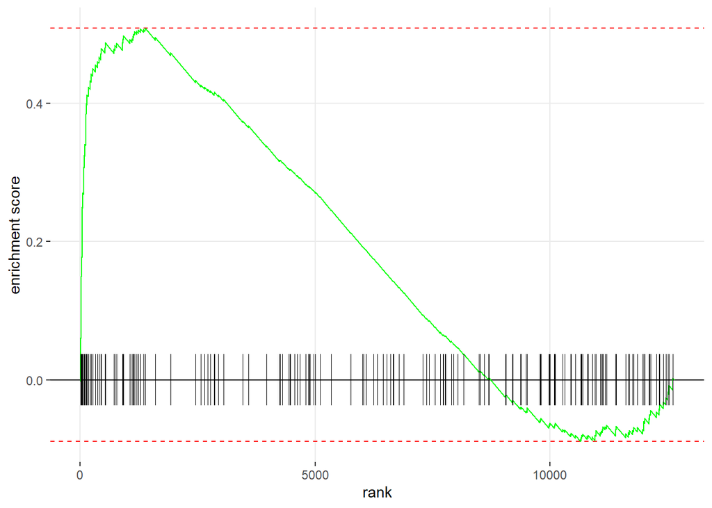

```r
plotEnrichment(aralists[["RESPONSE_TO_NITRATE"]],
               datalfc)
```

# Example with Human data.

Going back to the CF example, we can take the original DESeq2 results and perform a GSEA analysis.

```r
human_data = read.table("CF_DESeq2_results.txt")
head(human_data)
```

```
##         baseMean log2FoldChange      lfcSE       stat      pvalue       padj
## 1       81.11293     0.03768839 0.12052134  0.3127113 0.754499989 0.83664862
## 503538  50.66917     0.03307756 0.10878631  0.3040600 0.761082200 0.84132409
## 144571  97.27933    -0.46595182 0.32540707 -1.4319044 0.152171169 0.27464197
## 8086   125.24048     0.18476851 0.13571296  1.3614655 0.173366615 0.30122957
## 65985  166.57977    -0.15567513 0.05575343 -2.7922071 0.005234983 0.02207113
## 195827 198.55681     0.14686430 0.08570945  1.7135134 0.086618125 0.18335358
```

```r
dim(human_data)
```

```
## [1] 15570     6
```

We will use the msigdb to test many new gene sets that we have not previously tried.

```r
install.packages("msigdbr")
```

```r
library(msigdbr)
msigdbr_show_species()
```

```
##  [1] "Bos taurus"               "Caenorhabditis elegans"
##  [3] "Canis lupus familiaris"   "Danio rerio"
##  [5] "Drosophila melanogaster"  "Gallus gallus"
##  [7] "Homo sapiens"             "Mus musculus"
##  [9] "Rattus norvegicus"        "Saccharomyces cerevisiae"
## [11] "Sus scrofa"
```

The following step will allow us to load genesets for the human genome.

```r
m_df = msigdbr(species = "Homo sapiens")

m_df$entrez_gene = as.character(m_df$entrez_gene)

# create a list of gene sets.
human_pathways = split(m_df$entrez_gene, as.factor(m_df$gs_name))
```

Now let’s perform the analysis.

```r
library(fgsea)

expratio = human_data$log2FoldChange
names(expratio)=rownames(human_data)

humangsearesults = fgsea(human_pathways,
                       expratio,
                       minSize=10,
                       maxSize=500,
                       nperm=1000)

head(humangsearesults, 20)
```

```
##                     pathway        pval       padj         ES        NES
##  1:          AAACCAC_MIR140 0.005405405 0.05640888 -0.4904126 -1.5994347
##  2:          AAAGACA_MIR511 0.012371134 0.08534393 -0.4136518 -1.4239438
##  3:          AAAGGAT_MIR501 0.185577943 0.39999827 -0.3577672 -1.1840335
##  4:   AAAGGGA_MIR204_MIR211 0.001017294 0.02320679 -0.4837557 -1.6912336
##  5:       AAANWWTGC_UNKNOWN 0.098532495 0.27260836 -0.3722741 -1.2508466
##  6:       AAAYRNCTG_UNKNOWN 0.084677419 0.24891058 -0.3428954 -1.2159315
##  7:       AAAYWAACM_HFH4_01 0.014314928 0.09296582 -0.4098945 -1.4241724
##  8:        AACATTC_MIR4093P 0.299055614 0.53560156 -0.3322260 -1.1142076
##  9:          AACGGTT_MIR451 0.212076583 0.43408903 -0.5468793 -1.2383355
## 10:          AACTGAC_MIR223 0.050810811 0.18274121 -0.4229985 -1.3791850
## 11:          AACTGGA_MIR145 0.003058104 0.04286350 -0.4346503 -1.5196904
## 12:      AACWWCAANK_UNKNOWN 0.949473684 1.00000000 -0.2023489 -0.6754775
## 13:   AACYNNNNTTCCS_UNKNOWN 0.975929978 1.00000000 -0.1861952 -0.6042620
## 14:          AAGCAAT_MIR137 0.124872057 0.31336406 -0.3498546 -1.2114276
```

[output cut: 27 more lines]

```r
sig_humangsearesults = subset(humangsearesults, padj < 0.1)

head(sig_humangsearesults[order(sig_humangsearesults$padj),])
```

```
##                                                                                                        pathway
## 1:                                                                                       AAAGGGA_MIR204_MIR211
## 2:                                                                                       AATGTGA_MIR23A_MIR23B
## 3:                                                                                                ACCAAAG_MIR9
## 4:                                                                       ACEVEDO_METHYLATED_IN_LIVER_CANCER_DN
## 5:                                                                                       ACTGTGA_MIR27A_MIR27B
## 6: AGCACTT_MIR93_MIR302A_MIR302B_MIR302C_MIR302D_MIR372_MIR373_MIR520E_MIR520A_MIR526B_MIR520B_MIR520C_MIR520D
##           pval       padj         ES       NES nMoreExtreme size
## 1: 0.001017294 0.02320679 -0.4837557 -1.691234            0  184
## 2: 0.001002004 0.02320679 -0.4183629 -1.496779            0  324
## 3: 0.001000000 0.02320679 -0.4029297 -1.449941            0  398
## 4: 0.000999001 0.02320679 -0.4467828 -1.611207            0  417
## 5: 0.001002004 0.02320679 -0.3884996 -1.394433            0  363
## 6: 0.001007049 0.02320679 -0.4126238 -1.465852            0  277
##                              leadingEdge
## 1:    249,84255,9586,4651,1362,29982,...
## 2:    7039,8728,2649,5328,1602,57616,...
## 3:    4131,9828,9586,2571,11237,3778,...
## 4: 7544,55301,79623,2289,643036,3048,...
## 5:    5616,1432,602,8728,63035,64651,...
## 6: 284058,9828,9586,3778,57616,25946,...
```

If you would rather download only a subset of the database you can use the same technique as for Arabidopsis above.

First download a gmt file that has annotations you are interested. [Download](http://software.broadinstitute.org/gsea/msigdb/collections.jsp). For the example below I downloaded the go-term sets with entrez gene ids.

```r
human_go = gmtPathways("c5.all.v7.0.entrez.gmt")

humangogsearesults = fgsea(human_go,
                       expratio,
                       minSize=10,
                       maxSize=500,
                       nperm=1000)

head(humangogsearesults, 20)
```

```
##                                                                            pathway
##  1:                                  GO_POSITIVE_REGULATION_OF_VIRAL_TRANSCRIPTION
##  2:                                                 GO_CARDIAC_CHAMBER_DEVELOPMENT
##  3:                       GO_DNA_DEPENDENT_DNA_REPLICATION_MAINTENANCE_OF_FIDELITY
##  4:                                                            GO_CIRCADIAN_RHYTHM
##  5:                                                     GO_SPINAL_CORD_DEVELOPMENT
##  6:                   GO_PLATELET_DERIVED_GROWTH_FACTOR_RECEPTOR_SIGNALING_PATHWAY
##  7:                          GO_CELLULAR_RESPONSE_TO_LIPOPROTEIN_PARTICLE_STIMULUS
##  8:                      GO_POSITIVE_REGULATION_OF_EPITHELIAL_CELL_DIFFERENTIATION
##  9:                                      GO_POSITIVE_REGULATION_OF_KINASE_ACTIVITY
## 10:                                                     GO_POTASSIUM_ION_TRANSPORT
## 11:                             GO_REGULATION_OF_T_CELL_RECEPTOR_SIGNALING_PATHWAY
## 12:                        GO_NEGATIVE_REGULATION_OF_EPITHELIAL_CELL_PROLIFERATION
## 13: GO_MOVEMENT_IN_ENVIRONMENT_OF_OTHER_ORGANISM_INVOLVED_IN_SYMBIOTIC_INTERACTION
## 14:                            GO_REGULATION_OF_PROTEIN_TARGETING_TO_MITOCHONDRION
```

[output cut: 48 more lines]

```r
sig_humangogsearesults = subset(humangogsearesults, padj < 0.1)

head(sig_humangogsearesults[order(sig_humangogsearesults$padj),])
```

```
##                                       pathway        pval       padj         ES
## 1:  GO_POSITIVE_REGULATION_OF_KINASE_ACTIVITY 0.001000000 0.03372185 -0.4101199
## 2:                 GO_POTASSIUM_ION_TRANSPORT 0.001078749 0.03372185 -0.5437128
## 3:           GO_REGULATION_OF_CELL_ACTIVATION 0.001000000 0.03372185 -0.4142988
## 4:              GO_CYTOKINE_METABOLIC_PROCESS 0.001098901 0.03372185 -0.5205823
## 5: GO_NEGATIVE_REGULATION_OF_CELL_DEVELOPMENT 0.001016260 0.03372185 -0.4366528
## 6:                               GO_COGNITION 0.001034126 0.03372185 -0.4785592
##          NES nMoreExtreme size                           leadingEdge
## 1: -1.483709            0  429    6283,2180,2069,2258,60675,7039,...
## 2: -1.824247            0   96    6507,26251,3753,3772,3778,4905,...
## 3: -1.500129            0  435   57126,338339,383,8993,8876,2319,...
## 4: -1.721293            0   84   2069,602,246778,1051,3625,91662,...
## 5: -1.535023            0  191 10501,83999,23500,2258,64218,9856,...
## 6: -1.660541            0  161    2258,6484,3274,4311,4835,25946,...
```

# GOstats on human genome

```r
human_deg  = subset(human_data, padj < 0.05 &
                      abs(log2FoldChange) > 1)
dim(human_deg)
```

```
## [1] 322   6
```

```r
params=new("GOHyperGParams",
          geneIds = rownames(human_deg),
          universeGeneIds=rownames(human_data),
          annotation="org.Hs.eg",
          ontology="BP",
          pvalueCutoff=0.001,
          conditional=T,
          testDirection="over")
overRepresented=hyperGTest(params)

head(summary(overRepresented))
```

```
##       GOBPID       Pvalue OddsRatio  ExpCount Count Size
## 1 GO:0002263 1.871094e-17  5.722622 10.377788    45  618
## 2 GO:0002275 2.691709e-17  6.362656  8.194758    40  488
## 3 GO:0042119 1.029012e-16  6.426573  7.640604    38  455
## 4 GO:0002444 1.463390e-15  5.868831  8.278721    38  493
## 5 GO:0043312 1.767887e-15  6.162162  7.439094    36  443
## 6 GO:0045321 1.315594e-14  4.159329 16.809329    53 1001
##                                                  Term
## 1         cell activation involved in immune response
## 2 myeloid cell activation involved in immune response
## 3                               neutrophil activation
## 4                 myeloid leukocyte mediated immunity
## 5                            neutrophil degranulation
## 6                                leukocyte activation
```